# Introduction to Malaria Modeling Skills in R & RStudio using ML Algorithms

# Train a Decision Tree model

```r
set.seed(2024)
under.DTModel <- train(Malaria.Test~., data=under, method="rpart", trControl=control)
under.DTModel
```

```
CART

200 samples
 12 predictor
  2 classes: 'Negative', 'Positive'

No pre-processing
Resampling: Cross-Validated (10 fold, repeated 5 times)
Summary of sample sizes: 180, 180, 179, 179, 181, 179, ...
Resampling results across tuning parameters:

  cp         Accuracy   Kappa
  0.0000000  0.9249148  0.8486418
  0.4202128  0.9249148  0.8486418
  0.8404255  0.6845739  0.3390792

Accuracy was used to select the optimal model using the largest value.
The final value used for the model was cp = 0.4202128.
```

```r
under.DTpred=predict(under.DTModel,newdata = test)
under.DT.cM<- confusionMatrix(under.DTpred,as.factor(test$Malaria.Test), positive = 'Positive', mode='everything')
under.m8<- under.DT.cM$byClass[c(1, 2, 5, 7, 11)]
under.m8
```

```
      Sensitivity       Specificity         Precision                F1
        0.9189189         0.9294737         0.3366337         0.4927536
Balanced Accuracy
        0.9241963
```

```r
##plotting confusion matrix
under.DT.cM$table
```

```
          Reference
Prediction Negative Positive
  Negative      883        3
  Positive       67       34
```

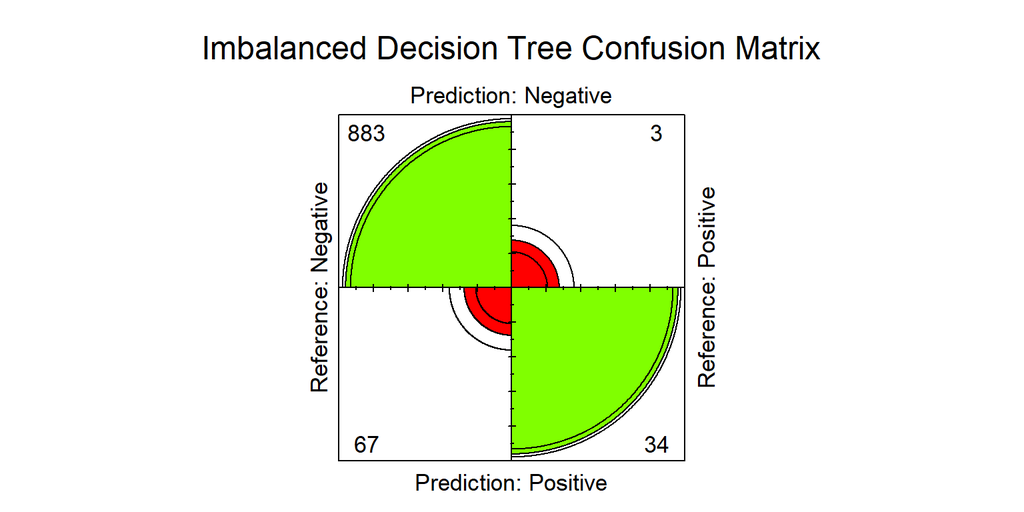

```r
fourfoldplot(under.DT.cM$table, col=rainbow(4), main="Imbalanced Decision Tree Confusion Matrix")
```

# Train a Bagging model

```r
set.seed(2024)
under.bagModel <- train(Malaria.Test~., data=under, method="treebag", trControl=control)
under.bagModel
```

```
Bagged CART

200 samples
 12 predictor
  2 classes: 'Negative', 'Positive'

No pre-processing
Resampling: Cross-Validated (10 fold, repeated 5 times)
Summary of sample sizes: 180, 180, 179, 179, 181, 179, ...
Resampling results:

  Accuracy  Kappa
  0.908     0.8152317
```

```r
under.bagpred=predict(under.bagModel,newdata = test)
under.bag.cM<- confusionMatrix(under.bagpred,as.factor(test$Malaria.Test), positive = 'Positive', mode='everything')
under.m9<- under.bag.cM$byClass[c(1, 2, 5, 7, 11)]
under.m9
```

```
      Sensitivity       Specificity         Precision                F1
        0.9729730         0.9157895         0.3103448         0.4705882
Balanced Accuracy
        0.9443812
```

```r
#plotting confusion matrix
under.bag.cM$table
```

```
          Reference
Prediction Negative Positive
  Negative      870        1
  Positive       80       36
```

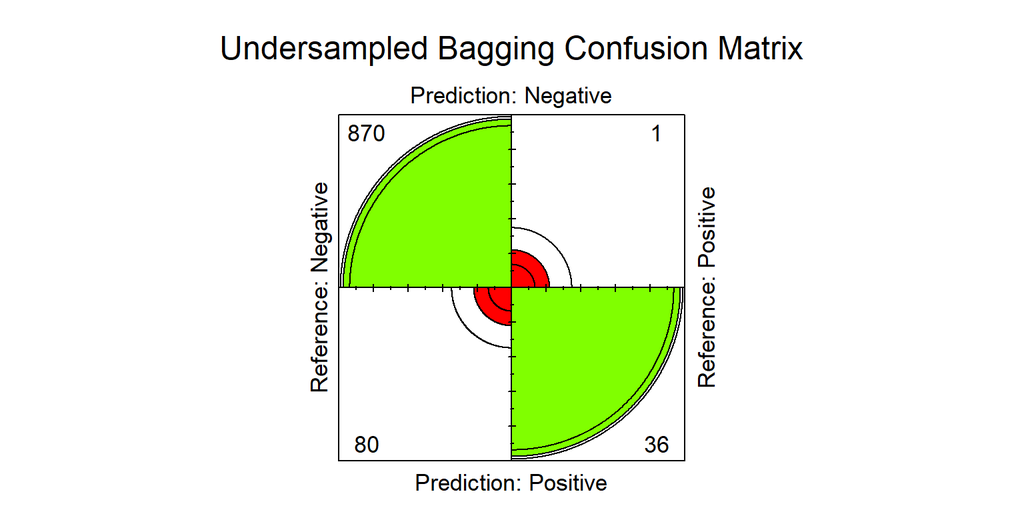

```r
fourfoldplot(under.bag.cM$table, col=rainbow(4), main="Undersampled Bagging Confusion Matrix")
```

# Train a Boosting model

```r
set.seed(2024)
tic()
under.boModel <- train(Malaria.Test~., data=under, method="ada", trControl=control)
toc()
```

```
279.7 sec elapsed
```

```r
under.boModel
```

```
Boosted Classification Trees

200 samples
 12 predictor
  2 classes: 'Negative', 'Positive'

No pre-processing
Resampling: Cross-Validated (10 fold, repeated 5 times)
Summary of sample sizes: 180, 180, 179, 179, 181, 179, ...
Resampling results across tuning parameters:

  maxdepth  iter  Accuracy   Kappa
  1          50   0.9249148  0.8486418
  1         100   0.9249148  0.8486418
  1         150   0.9229148  0.8445589
  2          50   0.9219574  0.8429043
  2         100   0.9101479  0.8190213
  2         150   0.9092481  0.8171948
  3          50   0.9121479  0.8230201
  3         100   0.9141479  0.8271378
  3         150   0.9101003  0.8190902

Tuning parameter 'nu' was held constant at a value of 0.1
Accuracy was used to select the optimal model using the largest value.
The final values used for the model were iter = 50, maxdepth = 1 and nu = 0.1.
```

```r
under.bopred=predict(under.boModel,newdata = test)
under.bo.cM<- confusionMatrix(under.bopred,as.factor(test$Malaria.Test), positive = 'Positive', mode='everything')
under.m10<- under.bo.cM$byClass[c(1, 2, 5, 7, 11)]
under.m10
```

```
      Sensitivity       Specificity         Precision                F1
        0.9189189         0.9294737         0.3366337         0.4927536
Balanced Accuracy
        0.9241963
```

```r
#plotting confusion matrix
under.bo.cM$table
```

```
          Reference
Prediction Negative Positive
  Negative      883        3
  Positive       67       34
```

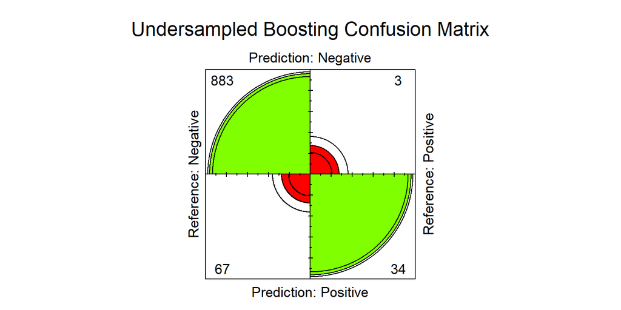

```r
fourfoldplot(under.bo.cM$table, col=rainbow(4), main="Undersampled Boosting Confusion Matrix")
```

# —————————-TABULATE THE MEASURES ————————————–

```r
measure <-round(data.frame(SVM= under.m1,
                                 RF= under.m2,
                                 LR = under.m3,
                                 KNN=under.m4,
                                 NB=under.m6,
                                 LDA=under.m7,
                                 DT=under.m8,
                                 Bagging = under.m9,
                                 Boosting = under.m10), 4)
rownames(measure)=c('Sensitivity', 'Specificity', 'Precision','F1-Score', 'Balanced Accuracy')
measure
```

```
                     SVM     RF     LR    KNN     NB    LDA     DT Bagging
Sensitivity       0.8919 0.9730 0.9730 0.8919 0.9459 0.9189 0.9189  0.9730
Specificity       0.9358 0.9147 0.9200 0.7737 0.9379 0.9295 0.9295  0.9158
Precision         0.3511 0.3077 0.3214 0.1331 0.3723 0.3366 0.3366  0.3103
F1-Score          0.5038 0.4675 0.4832 0.2316 0.5344 0.4928 0.4928  0.4706
Balanced Accuracy 0.9138 0.9439 0.9465 0.8328 0.9419 0.9242 0.9242  0.9444
                  Boosting
Sensitivity         0.9189
Specificity         0.9295
Precision           0.3366
F1-Score            0.4928
Balanced Accuracy   0.9242
```

# Collect all resamples and compare

```r
results <- resamples(list(SVM=under.svmModel,
                          RF=under.RFModel,
                          LR=under.lrModel,
                          KNN=under.knnModel,
                          NB=under.nbModel,
                          LDA=under.ldaModel,
                          Bagging=under.bagModel,
                          boosting=under.boModel))
```

# Summarize the distribution of the results

```r
summary(results)
```

```
Call:
summary.resamples(object = results)

Models: SVM, RF, LR, KNN, NB, LDA, Bagging, boosting
Number of resamples: 50

Accuracy
         Min.   1st Qu.    Median      Mean   3rd Qu.     Max. NA's
SVM      0.80 0.8947368 0.9473684 0.9249148 0.9523810 1.000000    0
RF       0.85 0.8665414 0.9473684 0.9250201 0.9523810 1.000000    0
LR       0.75 0.8517857 0.9000000 0.9070902 0.9500000 1.000000    0
KNN      0.60 0.7000000 0.7500000 0.7586015 0.8071429 0.952381    0
NB       0.75 0.8517857 0.9047619 0.9111003 0.9500000 1.000000    0
LDA      0.80 0.8947368 0.9473684 0.9249148 0.9523810 1.000000    0
Bagging  0.70 0.8571429 0.9000000 0.9080000 0.9500000 1.000000    0
boosting 0.80 0.8947368 0.9473684 0.9249148 0.9523810 1.000000    0

Kappa
              Min.   1st Qu.    Median      Mean   3rd Qu.      Max. NA's
SVM      0.5959596 0.7888889 0.8950276 0.8486418 0.9041096 1.0000000    0
RF       0.6875000 0.7353388 0.8950276 0.8492833 0.9049774 1.0000000    0
LR       0.5192308 0.7024194 0.7979798 0.8136264 0.9000000 1.0000000    0
KNN      0.1919192 0.4000000 0.5049020 0.5184110 0.6115156 0.9049774    0
NB       0.5192308 0.7024194 0.8090909 0.8214026 0.9000000 1.0000000    0
LDA      0.5959596 0.7888889 0.8950276 0.8486418 0.9041096 1.0000000    0
Bagging  0.4000000 0.7109911 0.7989899 0.8152317 0.9000000 1.0000000    0
boosting 0.5959596 0.7888889 0.8950276 0.8486418 0.9041096 1.0000000    0
```

# Box-and-whisker plot of results

This type of chart is used to visualize the distribution of data. It shows the following information: * The center of the data (usually the median) * The spread of the data (represented by the box) * The presence of any outliers (data points that fall outside a certain range)

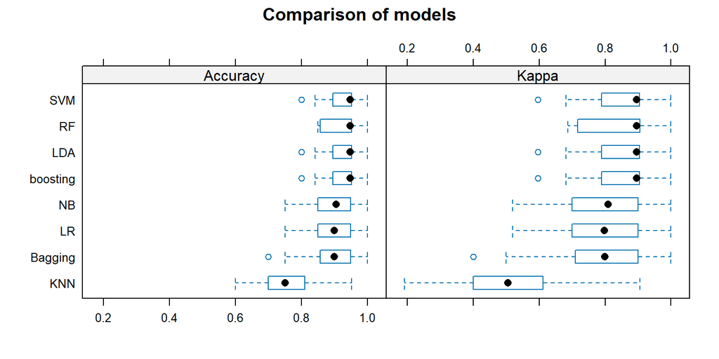

```r
bwplot(results, main ="Comparison of models")
```

# Dot plots of results

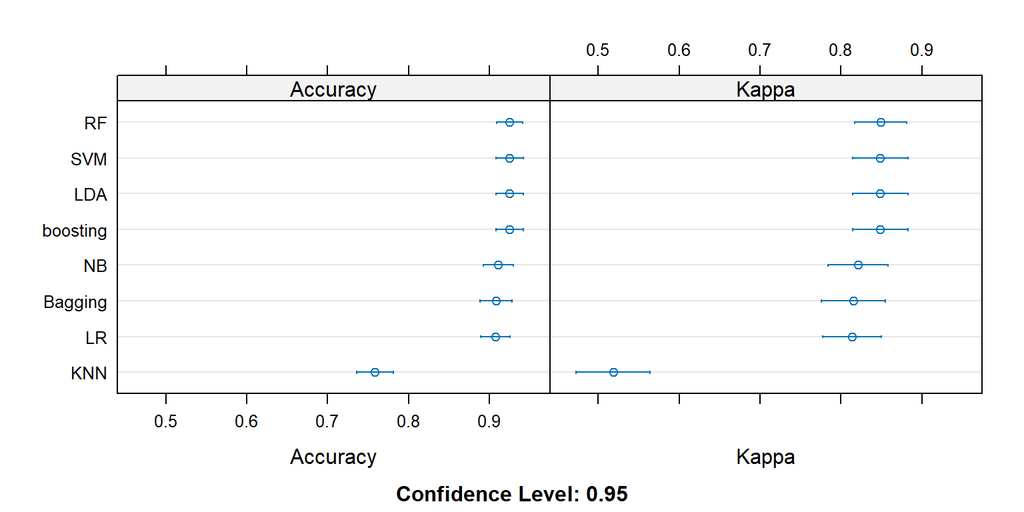

```r
dotplot(results)
```

# ———————————————————————————————-

# Handle Imbalanced: Hybrid Method

# ———————————————————————————————-

```r
library(dplyr)
hybrid <- ovun.sample(Malaria.Test~., data = train, method = "both")$data
dim(hybrid)
```

```
[1] 2293   13
```

# Plot Target variable using ggplot function

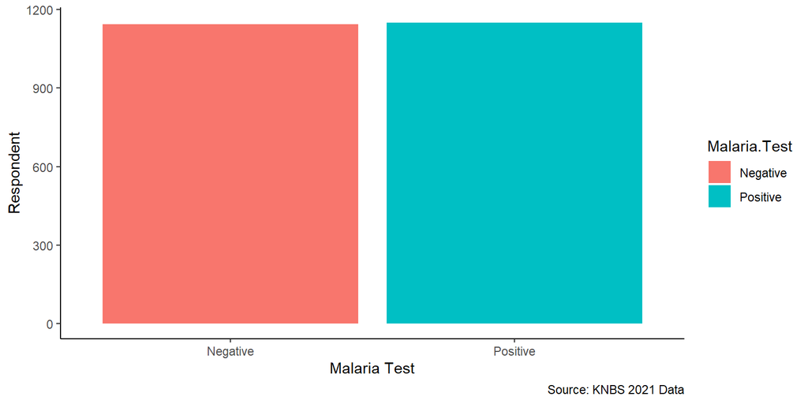

```r
ggplot(hybrid, aes(x = Malaria.Test, fill = Malaria.Test)) +
  geom_bar() +
  labs(x = "Malaria Test",
       y = "Respondent",
       tittle = "Malaria Diagnosis Results",
       caption = "Source: KNBS 2021 Data") +
    theme_classic()
```

# ———————————————————————————————- ## Building Machine Learning Models # ———————————————————————————————-

# prepare training scheme for cross-validation

```r
control <- trainControl(method="repeatedcv", number=10, repeats=5)
```

# Train a SVM model

```r
set.seed(2024)
tic()
both.svmModel <- train(Malaria.Test~., data=hybrid, method="svmRadial", trControl=control)
toc()
```

```
26.26 sec elapsed
```

```r
both.svmModel
```

```
Support Vector Machines with Radial Basis Function Kernel

2293 samples
  12 predictor
   2 classes: 'Negative', 'Positive'

No pre-processing
Resampling: Cross-Validated (10 fold, repeated 5 times)
Summary of sample sizes: 2063, 2064, 2064, 2064, 2064, 2063, ...
Resampling results across tuning parameters:

  C     Accuracy   Kappa
  0.25  0.9552576  0.9104963
  0.50  0.9608415  0.9216696
  1.00  0.9673822  0.9347558

Tuning parameter 'sigma' was held constant at a value of 0.06655531
Accuracy was used to select the optimal model using the largest value.
The final values used for the model were sigma = 0.06655531 and C = 1.
```

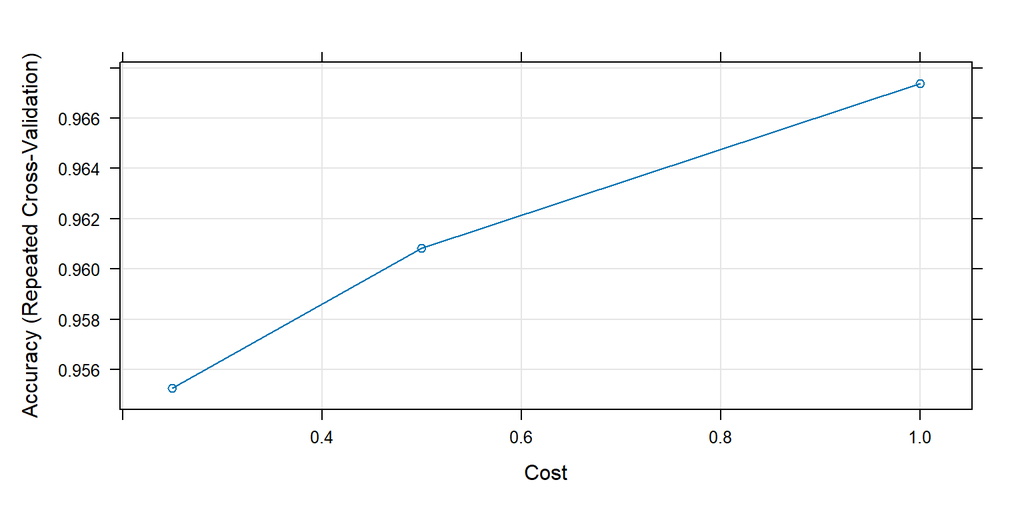

```r
plot(both.svmModel)
```

```r
both.svmpred=predict(both.svmModel,newdata = test)
both.SVM.cM<- confusionMatrix(both.svmpred,as.factor(test$Malaria.Test), positive = 'Positive', mode='everything')
both.SVM.cM
```

```
Confusion Matrix and Statistics

          Reference
Prediction Negative Positive
  Negative      876        2
  Positive       74       35

               Accuracy : 0.923
                 95% CI : (0.9046, 0.9389)
    No Information Rate : 0.9625
    P-Value [Acc > NIR] : 1

                  Kappa : 0.4486

 Mcnemar's Test P-Value : 3.816e-16

            Sensitivity : 0.94595
            Specificity : 0.92211
         Pos Pred Value : 0.32110
         Neg Pred Value : 0.99772
              Precision : 0.32110
                 Recall : 0.94595
                     F1 : 0.47945
             Prevalence : 0.03749
         Detection Rate : 0.03546
   Detection Prevalence : 0.11044
      Balanced Accuracy : 0.93403

       'Positive' Class : Positive
```

```r
both.m1<- both.SVM.cM$byClass[c(1, 2, 5, 7, 11)]
both.m1
```

```
      Sensitivity       Specificity         Precision                F1
        0.9459459         0.9221053         0.3211009         0.4794521
Balanced Accuracy
        0.9340256
```

```r
#plotting confusion matrix
both.SVM.cM$table
```

```
          Reference
Prediction Negative Positive
  Negative      876        2
  Positive       74       35
```

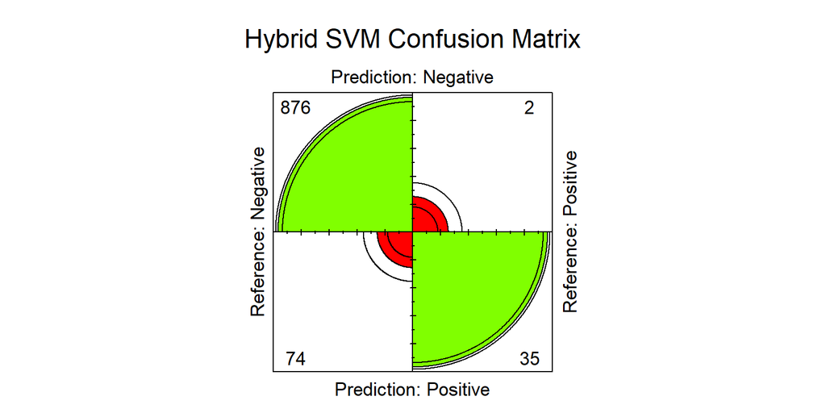

```r
fourfoldplot(both.SVM.cM$table, col=rainbow(4), main="Hybrid SVM Confusion Matrix")
```

# Train a Random Forest model

```r
set.seed(2024)
tic()
both.RFModel <- train(Malaria.Test~., data=hybrid, method="rf", trControl=control)
toc()
```

```
153.06 sec elapsed
```

```r
both.RFModel
```

```
Random Forest

2293 samples
  12 predictor
   2 classes: 'Negative', 'Positive'

No pre-processing
Resampling: Cross-Validated (10 fold, repeated 5 times)
Summary of sample sizes: 2063, 2064, 2064, 2064, 2064, 2063, ...
Resampling results across tuning parameters:

  mtry  Accuracy   Kappa
   2    0.9853476  0.9706924
   7    0.9902316  0.9804610
  12    0.9885745  0.9771461

Accuracy was used to select the optimal model using the largest value.
The final value used for the model was mtry = 7.
```

```r
both.RFpred=predict(both.RFModel,newdata = test)
both.RF.cM<- confusionMatrix(both.RFpred,as.factor(test$Malaria.Test), positive = 'Positive', mode='everything')
both.m2<- both.RF.cM$byClass[c(1, 2, 5, 7, 11)]
both.m2
```

```
      Sensitivity       Specificity         Precision                F1
        0.8918919         0.9484211         0.4024390         0.5546218
Balanced Accuracy
        0.9201565
```

```r
#plotting confusion matrix
both.RF.cM$table
```

```
          Reference
Prediction Negative Positive
  Negative      901        4
  Positive       49       33
```

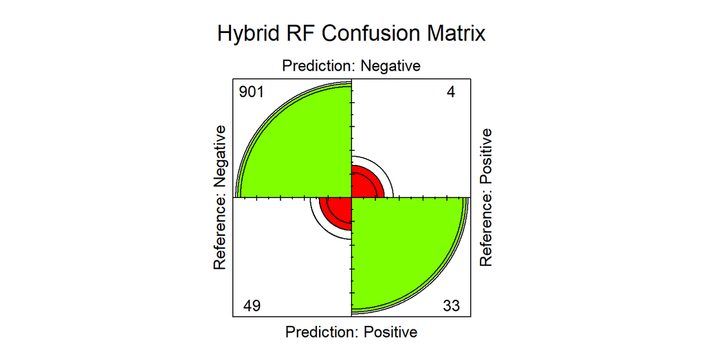

```r
fourfoldplot(both.RF.cM$table, col=rainbow(4), main="Hybrid RF Confusion Matrix")
```

# Train a Logisitic Regression model

```r
set.seed(2024)
both.lrModel <- train(Malaria.Test~., data=hybrid, method="glm", trControl=control)
both.lrModel
```

```
Generalized Linear Model

2293 samples
  12 predictor
   2 classes: 'Negative', 'Positive'

No pre-processing
Resampling: Cross-Validated (10 fold, repeated 5 times)
Summary of sample sizes: 2063, 2064, 2064, 2064, 2064, 2063, ...
Resampling results:

  Accuracy   Kappa
  0.9498508  0.8996938
```

```r
both.lrpred=predict(both.lrModel,newdata = test)
both.lr.cM<- confusionMatrix(both.lrpred,as.factor(test$Malaria.Test), positive = 'Positive', mode='everything')
both.m3<- both.lr.cM$byClass[c(1, 2, 5, 7, 11)]
both.m3
```

```
      Sensitivity       Specificity         Precision                F1
        0.9729730         0.9284211         0.3461538         0.5106383
Balanced Accuracy
        0.9506970
```

```r
#plotting confusion matrix
both.lr.cM$table
```

```
          Reference
Prediction Negative Positive
  Negative      882        1
  Positive       68       36
```

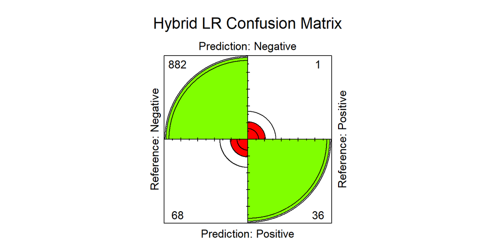

```r
fourfoldplot(both.lr.cM$table, col=rainbow(4), main="Hybrid LR Confusion Matrix")
```

# Train a k- Nearest Neigbour model

```r
set.seed(2024)
both.knnModel <- train(Malaria.Test~., data=hybrid, method="knn", trControl=control)
both.knnModel
```

```
k-Nearest Neighbors

2293 samples
  12 predictor
   2 classes: 'Negative', 'Positive'

No pre-processing
Resampling: Cross-Validated (10 fold, repeated 5 times)
Summary of sample sizes: 2063, 2064, 2064, 2064, 2064, 2063, ...
Resampling results across tuning parameters:

  k  Accuracy   Kappa
  5  0.9261234  0.8521795
  7  0.9003064  0.8004973
  9  0.8847822  0.7694175

Accuracy was used to select the optimal model using the largest value.
The final value used for the model was k = 5.
```

```r
both.knnpred=predict(both.knnModel,newdata = test)
both.knn.cM<- confusionMatrix(both.knnpred,as.factor(test$Malaria.Test), positive = 'Positive', mode='everything')
both.m4<- both.knn.cM$byClass[c(1, 2, 5, 7, 11)]
both.m4
```

```
      Sensitivity       Specificity         Precision                F1
        0.9189189         0.8410526         0.1837838         0.3063063
Balanced Accuracy
        0.8799858
```

```r
#plotting confusion matrix
both.knn.cM$table
```

```
          Reference
Prediction Negative Positive
  Negative      799        3
  Positive      151       34
```

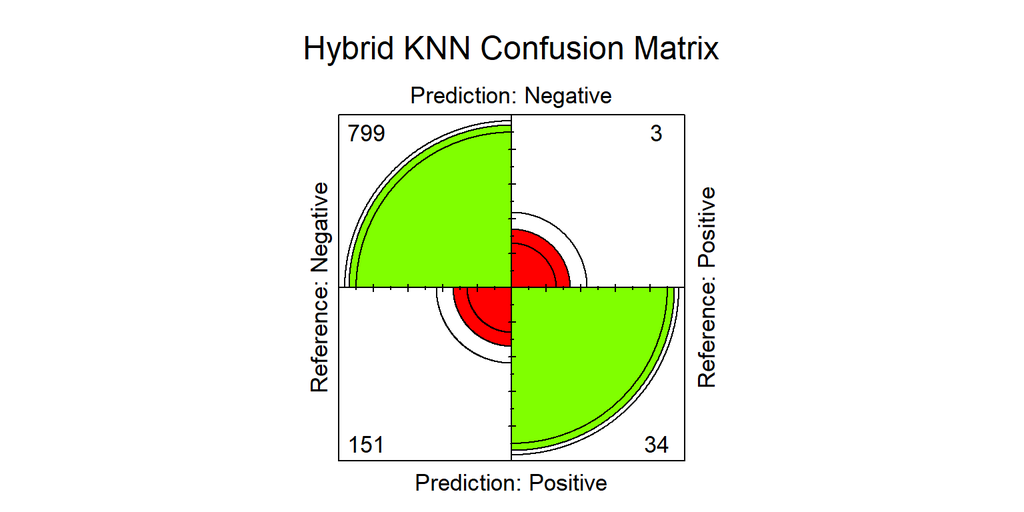

```r
fourfoldplot(both.knn.cM$table, col=rainbow(4), main="Hybrid KNN Confusion Matrix")
```

# Train a Neural Net model

```r
#set.seed(2024)
#tic()
#both.nnModel <- train(Malaria.Test~., data=hybrid, method="nnet", trControl=control)
#toc()
#both.nnModel
#both.nnpred=predict(both.nnModel,newdata = test)
#both.nn.cM<- confusionMatrix(both.nnpred,as.factor(test$Malaria.Test), positive = 'Positive', #mode='everything')
#both.m5<- both.nn.cM$byClass[c(1, 2, 5, 7, 11)]
#both.m5
#plotting confusion matrix
#both.nn.cM$table
#fourfoldplot(both.nn.cM$table, col=rainbow(4), main="Hybrid NN Confusion Matrix")
```